# NAD captureSeq

The goal of the project is to identify *Mycobacterium smegmatis* transcripts capped with NAD.

NAD captureSeq protocol info: https://www.nature.com/articles/nprot.2016.163

Initial dataset from 29. 3. 2019 consists of 12 libraries.

Design:

WT cells

- 3 biological replicates from EXPonential phase
- 3 biological replicates from STATionary phase

For each culture, an ADPRC-treated and mock-treated samples are available

The goal is to find transcripts enriched in the ADPRC-treated libraries compared to the mock controls.

Library fragment structure:

- 5’ adapter
- a short initial G-stretch (to be removed)
- actual cDNA (starting from the 5’ cap)
- UMI (7mer CNNNNNN)
- 3’ adapter with index

read length = 58 nt (often not enough to reach the UMI)

| sample | ADPRC | index |
| --- | --- | --- |
| 1E | + | 1 |
| 1E | - | 2 |
| 2E | + | 3 |
| 2E | - | 4 |
| 3E | + | 5 |
| 3E | - | 6 |
| 1S | + | 7 |
| 1S | - | 8 |
| 2S | + | 9 |
| 2S | - | 10 |
| 3S | + | 11 |
| 3S | - | 12 |

Initial quality checks (fastQC, mapping with HISAT2):

- large adapter contamination
- two populations of reads with different GC content (~43%, ~60%)
- large sequence duplication
- adapter-trimmed reads showed very low mappability (<1%)

```bash
clumpify.sh --version
cutadapt --version
```

```
## java -ea -Xmx8989m -Xms8989m -cp /opt/bbmap/current/ clump.Clumpify --version
## BBMap version 38.46
## For help, please run the shellscript with no parameters, or look in /docs/.
## 1.9.1
```

```bash
#Prepare required folders

fastq_dir="./FASTQ/"
fastq_collapse_dir="./FASTQ_UMIcollapsed/"
fastq_trim_dir="./FASTQ_trimmed/"
bam_dir="./BAM/"
mkdir -p "${fastq_collapse_dir}"
mkdir -p "${fastq_trim_dir}"
mkdir -p "${bam_dir}"

#Remove suspected PCR duplicates
#
#Mean library fragment size was ~400 bp. This means that UMI was likely not reached in the majority of reads, and cannot be used for deduplication.
#Therefore, all identical reads were simply collapsed to 1 copy (this removed the vast majority of reads = library had very low complexity).
#
#The procedure uses the `clumpify.sh` script from the BBMap package.
#
#https://github.com/BioInfoTools/BBMap
#
#https://github.com/BioInfoTools/BBMap/blob/master/sh/clumpify.sh

for i in `ls ${fastq_dir} | grep txt.gz`;
do
    clumpify.sh in="${fastq_dir}${i}" out="${fastq_collapse_dir}${i}.dedupe.gz" dedupe=t optical=f;
done

#Remove adapters using `trimmomatic`

for i in `ls ${fastq_collapse_dir} | grep $"dedupe.gz"`;
do
    java -jar /opt/Trimmomatic-0.39/trimmomatic-0.39.jar SE -phred33 \
        "${fastq_collapse_dir}${i}" "${fastq_trim_dir}${i}.trimmomatic" \
        ILLUMINACLIP:/opt/Trimmomatic-0.39/adapters/TruSeq3-SE.fa:2:30:10;
done

for i in `ls ${fastq_trim_dir} | grep $"trimmomatic"`;
do
    gzip "${fastq_trim_dir}${i}" "${fastq_trim_dir}${i}.gz"
done

#Collapse the leading G-stretch of variable length to a single G using `UrQt.1.0.18`
#
#https://github.com/l-modolo/UrQt

for i in `ls ${fastq_trim_dir} | grep $"trimmomatic.gz"`;
do
    /opt/UrQt/UrQt --in "${fastq_trim_dir}${i}" --out "${fastq_trim_dir}${i}.UrQt.fastq.gz" --pos head --N G --t 2 --m 4 --gz
done

#Perform final trimming with `cutadapt`
#
#* remove the leading single G
#* remove the potential UMI tail (= last 7 nt)
#* discard reads shorter than 20 nt

for i in `ls ${fastq_trim_dir} | grep $"UrQt.fastq.gz"`;
do
    cutadapt --cut=-7 --cut=1 --minimum-length=20 -o "${fastq_trim_dir}${i}.cutadapt" "${fastq_trim_dir}${i}"
done

for i in `ls ${fastq_trim_dir} | grep $"cutadapt"`;
do
    gzip "${fastq_trim_dir}${i}" "${fastq_trim_dir}${i}.gz"
done

#Map clean reads into *M. smegmatis* genome (https://www.ncbi.nlm.nih.gov/nuccore/NC_008596) using HISAT2 and samtoools.
#
#Note: The genome also contains the sequences of recombinase and kanamycin resistance marker used for Ms1 knock-out generation, but these are not relevant for this project.

maplog_file="./mapping.log"
Q=10     # mapping quality score threshold for keeping reads in final BAM files
CPU=4   # number of available CPUs
HISAT2_index="./genome/M_smegmatisMC2_155_plus_recombinase"
rm -f "${maplog_file}" # clean log file
for i in `ls ${fastq_trim_dir} | grep $"cutadapt.gz"`;
do
    infile="${fastq_trim_dir}${i}"
    outfile="${bam_dir}${i}.bam"
    echo "############################################" >> "${maplog_file}" 2>&1
    date >> "${maplog_file}" 2>&1
    echo "HISAT2 processing file: ${infile}" >> "${maplog_file}" 2>&1
    echo "############################################" >> "${maplog_file}" 2>&1
    hisat2 -x "${HISAT2_index}" -U "${infile}" --threads "${CPU}" --rna-strandness F --summary-file "${outfile}.log" --no-spliced-alignment | samtools view -b -q "${Q}" --threads "${CPU}" - | samtools sort -o "${outfile}" - >> "${maplog_file}" 2>&1
    samtools index "${outfile}" >> "${maplog_file}" 2>&1
    samtools flagstat "${outfile}" >> "${maplog_file}" 2>&1
    echo >> "${maplog_file}" 2>&1
    echo
done
```

Mappability was still very low (typically thousands/tens of thousands of reads per sample) but visual inspection in IGV suggested there are promising candidate loci with narrow pileups at the transcription start sites.

- corresponding ORFs are typically short (300-400 bp)
- at some loci (tRNA, rRNA) there are pileups in all samples (= including mock controls); at other loci pileups are specific for ADPRC-treated samples
- some putative candidates do not contain pileups in one or two samples, which is likely a stochastic event due to very low read coverage

Many read pileups are in intergenic/non-ORF regions (= not covered by ORF annotation). To be able to quantitatively capture all such pileups, a version of genome annotation is needed that would cover the whole genome (=ORFs & “intergenic regions”). Note: the original NCBI GFF file was appended to include Ms1 and rnpB features

```r
gff_all <- './genome/GCF_000015005.1_ASM1500v1_genomic_Ms1_rnpB.gff'
gff_genes <- './genome/GCF_000015005.1_ASM1500v1_genomic_Ms1_rnpB.genes.gff'

gff <- gffRead(gff_all)
```

```
## Reading ./genome/GCF_000015005.1_ASM1500v1_genomic_Ms1_rnpB.gff: found 13770 rows with classes: character, character, character, integer, integer, character, character, character, character
```

```r
gff <- gff[gff$feature == 'gene',]
gff <- gff[order(gff$start), ]
gff_header <- grep(pattern = '#', readLines(gff_all), value = TRUE)
writeLines(gff_header, gff_genes)
write.table(gff, gff_genes, append = TRUE, sep = '\t', quote = FALSE, col.names = FALSE, row.names = FALSE)
```

```bash
GFF_genes="./genome/GCF_000015005.1_ASM1500v1_genomic_Ms1_rnpB.genes.gff"
GFF_intergenic="./genome/GCF_000015005.1_ASM1500v1_genomic_Ms1_rnpB.intergenic.gff"
genome="./genome/genome.size"
bedtools --version
bedtools complement -i "${GFF_genes}" -g "${genome}" > "${GFF_intergenic}"
```

```
## bedtools v2.25.0
```

```r
gff_intergenic <- './genome/GCF_000015005.1_ASM1500v1_genomic_Ms1_rnpB.intergenic.gff'
gff_genes_inter <- './genome/GCF_000015005.1_ASM1500v1_genomic_Ms1_rnpB.genes+intergenic.gff'

intergenic <- read.delim(gff_intergenic, comment.char = '#', header = FALSE, stringsAsFactors = FALSE)
intergenic <- as.data.frame(cbind(intergenic[, 1], 'RefSeq', 'gene', intergenic[, 2], intergenic[, 3], '.', '*', '.', NA), stringsAsFactors = FALSE)
colnames(intergenic) <- colnames(gff)
intergenic$start <- as.numeric(intergenic$start) + 1
intergenic$end <- as.numeric(intergenic$end)
gff <- rbind(gff, intergenic)
gff <- gff[order(gff$start), ]
gff$Name <- getAttributeField(gff$attributes, 'Name')
for(i in 1:nrow(gff)) {
  if(is.na(gff[i, 'Name'])){
    gff[i, 'attributes'] <- paste('Name=intergenic', gff[i-1, 'Name'], gff[i + 1, 'Name'], sep = '_')
  }
}
gff <- gff[, 1:9]
gff$Name <- getAttributeField(gff$attributes, 'Name')
gff$Gene_ID <- getAttributeField(gff$attributes, 'locus_tag')

writeLines(gff_header, gff_genes_inter)
write.table(gff[, -10], gff_genes_inter, append = TRUE, sep = '\t', quote = FALSE, col.names = FALSE, row.names = FALSE)

## sanity check
#tmp <- NA
#for(i in 2:nrow(gff)) {
#  tmp <- c(tmp, gff[i, "start"] - gff[i - 1, "end"])
#}
#gff[which(tmp == max(tmp, na.rm = T)) - 2, ]
#gff[which(tmp == max(tmp, na.rm = T)) - 1, ]
```

Create count table for identification of read enrichment

```r
bam <- BamFileList(list.files('./BAM/',
                              pattern = '\\.bam$',
                              full.names = TRUE),
                   asMates = FALSE,
                   yieldSize = 1000000)

gene_features <- GRanges(seqnames = 'gi|118467340|ref|NC_008596.1|',
                         ranges = IRanges(start = gff$start, end = gff$end),
                         strand = gff$strand)

se <- summarizeOverlaps(features = gene_features,
                        reads = bam,
                        mode = 'Union',
                        singleEnd = TRUE,
                        ignore.strand = FALSE)
sampleInfo <- data.frame(t(read.csv('sampleInfo', sep = '\t', header = FALSE)))
colnames(sampleInfo) <- c('run', 'treatment', 'file', 'phase')
colData(se) <- cbind(colData(se), sampleInfo) # must use cbind; direct assignment ('=') does not work
colnames(se) <- paste(se$treatment, se$phase, se$run, sep = '_')
rownames(se) <- gff$Name

counts <- assay(se)
counts <- counts[, sort(colnames(counts))]
rownames(counts) <- gff$Name
write.csv(counts, file = 'counts.txt', quote = FALSE)
save(file = 'se.rda', se)

colSums(counts)
```

```
##  ADPRC_EXP_1  ADPRC_EXP_2  ADPRC_EXP_3 ADPRC_STAT_1 ADPRC_STAT_2
##         2599         2153       118582        20918        14300
## ADPRC_STAT_3   mock_EXP_1   mock_EXP_2   mock_EXP_3  mock_STAT_1
##       264275         3277         1569        35765         5259
##  mock_STAT_2  mock_STAT_3
##         1607        17708
```

Total counted reads per sample (`colSums(counts)`) compared with mapping statistics for each sample → looks OK

Identify regions with significantly enriched read coverage using DESeq2

```r
# Benjamini-Hochberg p value adjustment (FDR)
padj.threshold <- 0.05

# sample QC
ddsFull <- DESeqDataSet(se, design = ~ run + phase + treatment) # IMPORTANT !!! the experimental variable must be last, control variables first
ddsFull <- DESeq(ddsFull)
```

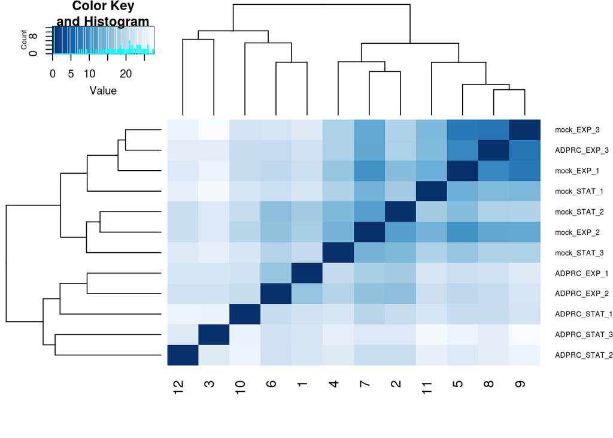

```r
rld <- rlog(ddsFull)
sampleDist <- dist(t(assay(rld)))
sampleDistMatrix <- as.matrix(sampleDist)
rownames(sampleDistMatrix) <- paste(rld$treatment, rld$phase, rld$run, sep = '_')
colnames(sampleDistMatrix) <- NULL
colours <- colorRampPalette(rev(brewer.pal(9, 'Blues')))(255)
heatmap.2(sampleDistMatrix, trace = 'none', col = colours, cexRow = 0.6)
```

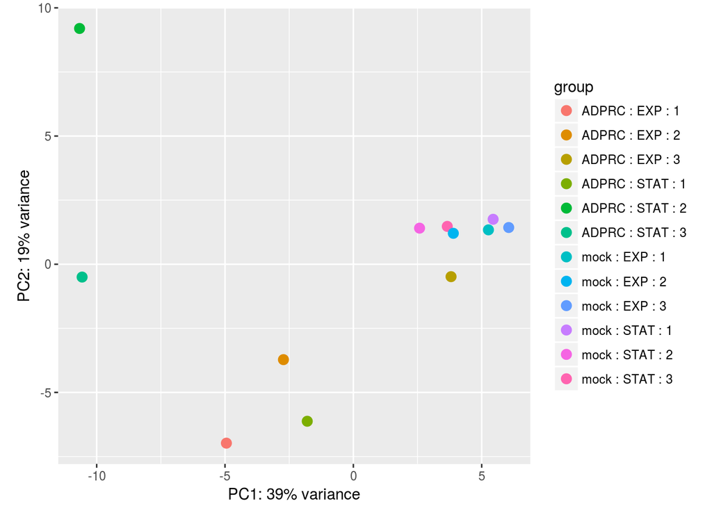

```r
ramp <- 1:3/3
cols <- c(rgb(ramp, 0, 0), rgb(0, ramp, 0), rgb(0, 0, ramp))
print(plotPCA(rld, intgroup = c('treatment', 'phase', 'run')))
```

```r
# DEG identification
# EXPonential phase, ADPRC-treated vs mock
ddsExp <- DESeqDataSet(se, design = ~ run + treatment)
ddsExp <- ddsExp[, ddsExp$phase == 'EXP'] # remove samples from unwanted growth phases
ddsExp$phase <- droplevels(ddsExp$phase)
ddsExp$treatment <- relevel(ddsExp$treatment, 'mock') # change order of factor levels to get ADPRC/mock fold change
ddsExp <- DESeq(ddsExp)
resExp <- results(ddsExp)
write.csv(resExp, file = 'DESeq2results_EXP.txt', quote = FALSE)
resExp.sig <- resExp[which(resExp$padj < padj.threshold), ]
resExp.sig <- resExp.sig[order(resExp.sig$log2FoldChange), ]
write.csv(resExp.sig, file = 'DESeq2results_EXP.SIG.txt', quote = FALSE)

# STATonential phase, ADPRC-treated vs mock
ddsStat <- DESeqDataSet(se, design = ~ run + treatment)
ddsStat <- ddsStat[, ddsStat$phase == 'STAT'] # remove samples from unwanted growth phases
ddsStat$phase <- droplevels(ddsStat$phase)
ddsStat$treatment <- relevel(ddsStat$treatment, 'mock') # change order of factor levels to get ADPRC/mock fold change
ddsStat <- DESeq(ddsStat)
resStat <- results(ddsStat)
write.csv(resStat, file = 'DESeq2results_STAT.txt', quote = FALSE)
resStat.sig <- resStat[which(resStat$padj < padj.threshold), ]
resStat.sig <- resStat.sig[order(resStat.sig$log2FoldChange), ]
write.csv(resStat.sig, file = 'DESeq2results_STAT.SIG.txt', quote = FALSE)
```

DESeq2 returned only few DEGs for the exponential phase and no DEGs for the stationary phase. Moreover, most “DEGs” seem to contain reads in both ADPRC-treated and mock controls (but enriched in ADPRC-treated samples). Apparently, DESeq2 is not suitable for this very-low-coverage dataset. The tools cannot build its statistical models when counts are close to zero, so most genes cannot be analyzed with DESeq2.

Therefore, a less sophisticated approach was used:

- for each sample, respective gene counts were normalized to the total number of counts in the sample (and multiplied by 10^6; `counts.lib_norm`)
- library-normalized counts from the three biological repeats were pooled (i.e., added together; `counts.lib_norm.pool`)
- exponential (EXP)- and stationary (STAT)-phase pooled library-normalized counts were further normalized to the corresponding mock-treated control (`counts.lib_norm.pool.ctrl_norm`)

```r
counts.lib_norm <- counts
for (i in 1:ncol(counts)){
  counts.lib_norm[, i] <- counts[, i] / colSums(counts)[i] * 1000000
}
counts.lib_norm.pool <- cbind(rowSums(counts.lib_norm[, 1:3]),
                              rowSums(counts.lib_norm[, 4:6]),
                              rowSums(counts.lib_norm[, 7:9]),
                              rowSums(counts.lib_norm[, 10:12]))
colnames(counts.lib_norm.pool) <- c('ADPRC_EXP', 'ADPRC_STAT', 'mock_EXP', 'mock_STAT')
counts.lib_norm.pool.ctrl_norm <- cbind(counts.lib_norm.pool[, 1] / counts.lib_norm.pool[, 3],
                                        counts.lib_norm.pool[, 2] / counts.lib_norm.pool[, 4])
colnames(counts.lib_norm.pool.ctrl_norm) <- c('EXP', 'STAT')
write.csv(counts.lib_norm, file = 'counts.lib_norm.txt', quote = FALSE)
write.csv(counts.lib_norm.pool, file = 'counts.lib_norm.pool.txt', quote = FALSE)
write.csv(counts.lib_norm.pool.ctrl_norm, file = 'counts.lib_norm.pool.ctrl_norm.txt', quote = FALSE)
```

Upon visual inspection in IGV of top candidates (highest values in `counts.lib_norm.pool.ctrl_norm`) the approach seems to be useful, though certainly not perfect (it is sensitive to outlier samples with high read counts for a given gene).